# Predicting Flight Time

Eric Feder

Note: The .Rmd file and the accompanying csv files can be found [here](https://github.com/ef2240/flights).

### Objective

I would like to see what factors are predictive of a flight’s actual elapsed time and how strong of a model I might be able to build. For purposes of this project, I am ignoring any delays that come before the plane leaves the departure gate, and am looking exclusively at the time elapsed from departure until arrival.

### Data processing

The steps below cover the data import and basic formatting of variables. The files in the Input_data/ folder cover 24 months of flight data, downloaded from [this link](http://www.transtats.bts.gov/DL_SelectFields.asp?Table_ID=236&DB_Short_Name=On-Time).

```r
# # Install packages
# install.packages("data.table")
# install.packages("ggplot2")
# install.packages("gbm")
# install.packages("cvTools")

# Load package
library(data.table)
library(ggplot2)
library(gbm)
library(cvTools)

# Read in data
flight.files <- list.files("Input_data/", full.names=T)
flights.list <- lapply(flight.files, read.csv)

# Merge data frames into one large data table
flights <- rbindlist(flights.list)

# Convert DAY_OF_WEEK AND MONTH to factors
flights$DAY_OF_WEEK <- factor(flights$DAY_OF_WEEK)
flights$MONTH <- factor(flights$MONTH)
```

#### Selecting a data sample

To reduce the size of my dataset and reduce the potential impact of outliers, I narrowed my analysis to flights that both depart from, and arrive at, one of the twenty most popular airports. I also removed cancelled and diverted flights (i.e. flights with no actual ellapsed time) from the sample, to simplify the analysis.

```r
# Filter out flights that got cancelled or diverted
flights.arrived <- flights[!is.na(ACTUAL_ELAPSED_TIME)]

# Filter to paths between top 20 airports (using Origin or Destination airports yield identical lists)
top20.airports <- flights.arrived[, .N, by=ORIGIN][order(N, decreasing=T)][1:20, ORIGIN]
flights.top.airports <- flights.arrived[ORIGIN %in% top20.airports & DEST %in% top20.airports]
```

### Exploratory analysis

#### Day of the Week

The plot below suggests no significant variations in flight time by day of the week. Hence, I did not include it as one of my predictor variables.

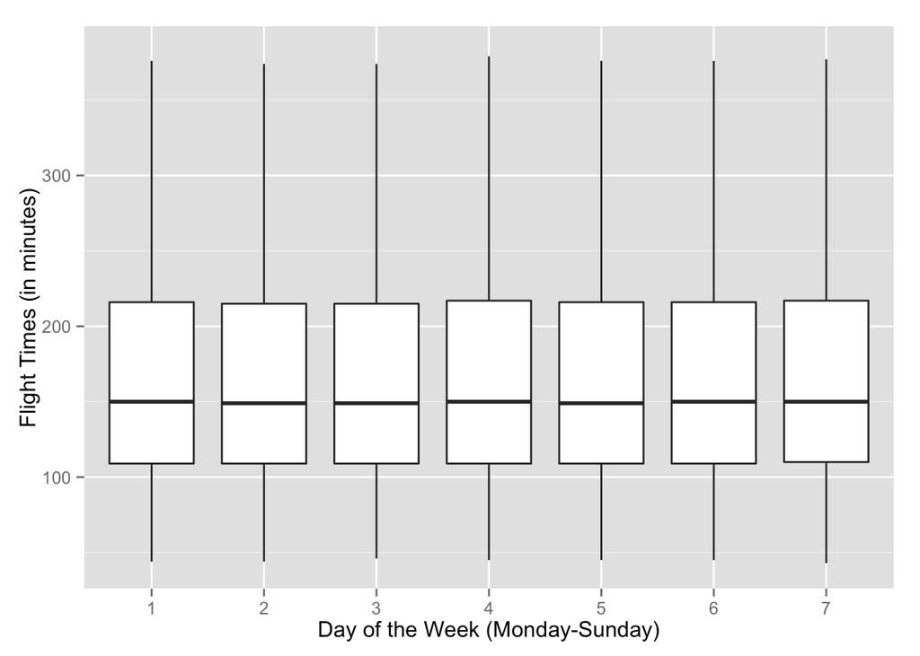

```r
# Save preferred background aesthetics (no grid, no background color) as object
no.bg <- theme(panel.grid.major = element_blank(), panel.grid.minor = element_blank(), panel.background = element_blank(), axis.line = element_line(colour = "black"))

# Find flight time by day of week
day.of.week.plot <- ggplot(flights.top.airports, aes(x=DAY_OF_WEEK, y=ACTUAL_ELAPSED_TIME)) + geom_boxplot(outlier.shape=NA)
boxplot.ylim <- boxplot.stats(flights.top.airports$ACTUAL_ELAPSED_TIME)$stats[c(1, 5)]
day.of.week.plot + ylim(boxplot.ylim) + xlab("Day of the Week (Monday-Sunday)") + ylab("Flight Times (in minutes)")
```

#### Distance

I found that the flight’s distance is, unsurprisingly, strongly correlated with the flight’s time. I made the points semi-transparent to handle overplotting.

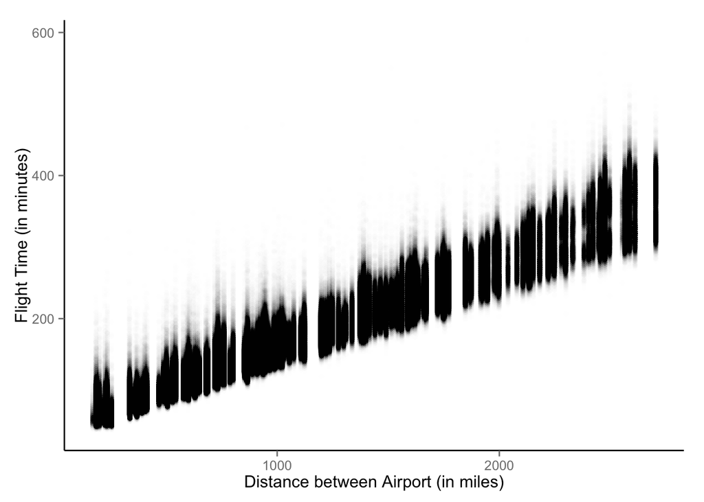

```r
# Compare distance to flight time
flight.vs.distance.plot <- ggplot(flights.top.airports, aes(x=DISTANCE, y=ACTUAL_ELAPSED_TIME))
flight.vs.distance.plot + geom_point(alpha=0.003) + no.bg + xlab("Distance between Airport (in miles)") + ylab("Flight Time (in minutes)")
```

```r
# Find correlation between flight time and flight distance
cor(flights.top.airports$DISTANCE, flights.top.airports$ACTUAL_ELAPSED_TIME)
```

```
## [1] 0.9687511
```

Since Distance is such a significant predictor, in my further exploratory analysis, I will see whether additional variables can explain any of the variance in flight time that Distance was unable to (i.e. the residual between the actual flight time and the flight time expected based solely on Distance).

```r
# Fit linear regression just based on Distance and residuals to flights data table
distance.model <- lm(ACTUAL_ELAPSED_TIME ~ DISTANCE, data=flights.top.airports)
flights.top.airports$elapsed.resid <- resid(distance.model)
```

#### Time of Day

While flights that depart between 7AM and 9PM, on average, last as long as would be expected based on their distances, flights that depart at night or early in the morning, tend to be shorter than expected. With more time, I would have liked to examine whether there were any other meaningful differences between these two sets of flights that could be confounding variables. (For instance, perhaps some routes only depart at night.) However, for my analysis, I will assume that time of day has at least some predictive power.

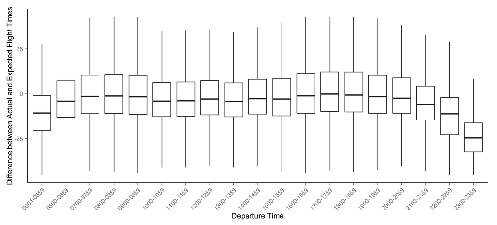

```r
# Save object to rotate x-axis labels 45 degrees
rotate45 <- theme(axis.text.x=element_text(angle=45, hjust=1))

# Does time of day matter?
dep.time.resid.plot <- ggplot(flights.top.airports, aes(x=DEP_TIME_BLK, y=elapsed.resid)) + geom_boxplot(outlier.shape=NA)
boxplot.ylim <- boxplot.stats(flights.top.airports$elapsed.resid)$stats[c(1, 5)]
dep.time.resid.plot + ylim(boxplot.ylim) + no.bg + xlab("Departure Time") + ylab("Difference between Actual and Expected Flight Times") + rotate45
```

#### Month

The plot below suggests some degree of seasonality, as flights in the winter tend to take longer than would be expected based on their distances, perhaps a result of inclement weather. However, because the differences are so small (less than five minutes even at the extremes), I decided not to include it in my model.

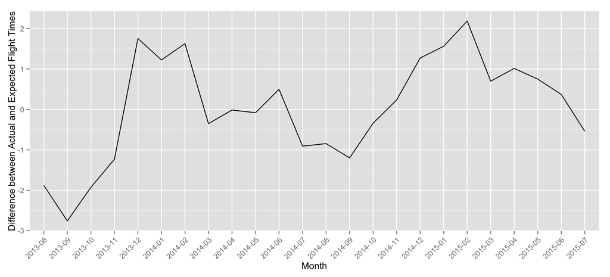

```r
# Is there seasonality?
mean.resid.by.month <- flights.top.airports[, list(mean.resid=mean(elapsed.resid)), by=list(month.yr=sprintf("%d-%02.f", YEAR, MONTH))]
seasonality.plot <- ggplot(mean.resid.by.month, aes(x=month.yr, y=mean.resid, group=1))
seasonality.plot + geom_line() + xlab("Month") + ylab("Difference between Actual and Expected Flight Times") + rotate45
```

#### Departure and Arrival Airport

Running an ANOVA test suggests that the departure and arrival airports have predictive power, even after accounting for flights distances.

```r
# Are origin and destination airports important?
aov.origin <- aov(elapsed.resid ~ ORIGIN, data=flights.top.airports)
summary(aov.origin)
```

```
##                  Df    Sum Sq  Mean Sq F value Pr(>F)
## ORIGIN           19 311586805 16399306   58324 <2e-16 ***
## Residuals   2716009 763675095      281
## ---
## Signif. codes:  0 '***' 0.001 '**' 0.01 '*' 0.05 '.' 0.1 ' ' 1
```

```r
aov.dest <- aov(elapsed.resid ~ DEST, data=flights.top.airports)
summary(aov.dest)
```

```
##                  Df    Sum Sq Mean Sq F value Pr(>F)
## DEST             19 103540687 5449510   15232 <2e-16 ***
## Residuals   2716009 971721213     358
## ---
## Signif. codes:  0 '***' 0.001 '**' 0.01 '*' 0.05 '.' 0.1 ' ' 1
```

Interestingly, I discovered that flights which originate at airports on the East Coast tended to have positive residuals. However, when flights land at airports on the East Coast, they tended to have negative residuals. Furthermore, the reverse was true for airports on the West Coast. It seems that eastbound flights are quicker than westbound flights, perhaps due to wind patterns. With more time, I would have liked to encode a flight’s direction as an explicit predictor variable.

```r
# Does direction matter?
origin.resid <- flights.top.airports[, list(origin.mean.resid=mean(elapsed.resid)), keyby=ORIGIN]
dest.resid <- flights.top.airports[, list(dest.mean.resid=mean(elapsed.resid)), keyby=DEST]
origin.resid[dest.resid]
```

```
##     ORIGIN origin.mean.resid dest.mean.resid
##  1:    ATL         3.4409998     -3.96324984
##  2:    BOS        16.9458988    -11.69579423
##  3:    BWI         4.6908258     -9.65531708
##  4:    CLT         6.4306333     -2.05159680
##  5:    DEN        -8.1535495      0.46791641
##  6:    DFW        -2.0315791      2.87323688
##  7:    DTW         5.5123347     -3.27004635
##  8:    EWR        16.8704719     -8.11378609
##  9:    IAH        -0.2380742     -0.55075255
## 10:    JFK        25.8083033    -10.84845916
## 11:    LAS        -9.8854373      2.01190213
## 12:    LAX       -11.8299630      9.51626558
## 13:    LGA        18.9443405     -3.33603501
## 14:    MCO         1.7301965     -3.41637015
## 15:    MSP        -0.3656944     -3.23154683
## 16:    ORD         3.1271300      3.26862500
## 17:    PHX       -10.4812732      2.19858378
## 18:    SEA       -11.8773871      8.34077358
## 19:    SFO       -12.4872983     10.12729687
## 20:    SLC        -7.4876407      0.02324951
```

#### Carrier

Finally, the differences between carriers seem to be significant enough to warrant including the flight’s carrier as a predictor variable.

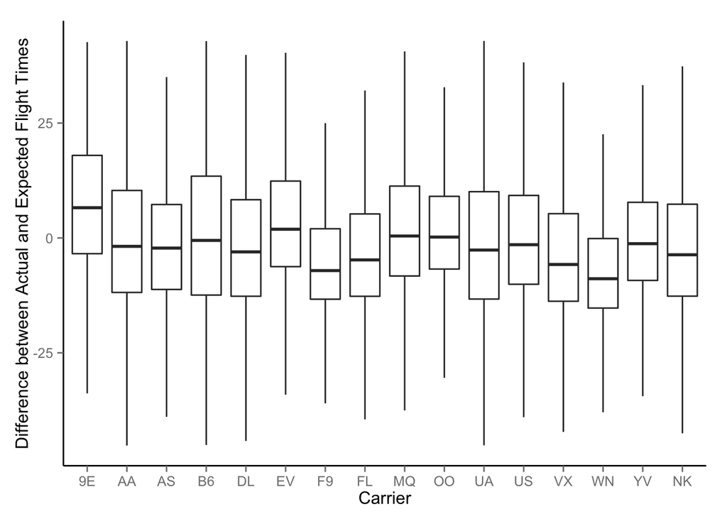

```r
# Is carrier significant?
carrier.resid.plot <- ggplot(flights.top.airports, aes(x=CARRIER, y=elapsed.resid)) + geom_boxplot(outlier.shape=NA)
boxplot.ylim <- boxplot.stats(flights.top.airports$elapsed.resid)$stats[c(1, 5)]
carrier.resid.plot + ylim(boxplot.ylim) + no.bg + xlab("Carrier") + ylab("Difference between Actual and Expected Flight Times")
```

### Model Fitting

#### Choice of predictor variables

Based on the exploratory analysis above, I will use the following variables as model inputs:

- carrier
- origin
- destination
- departure time (based on hour of the day)
- distance

```r
# Drop variables not needed for modeling
flights.top.airports[, c("YEAR", "MONTH", "DAY_OF_WEEK", "elapsed.resid") := NULL]
```

```
##          CARRIER ORIGIN DEST DEP_TIME_BLK CRS_ELAPSED_TIME
##       1:      9E    DFW  DTW    0900-0959              164
##       2:      9E    ORD  MSP    1000-1059               88
##       3:      9E    ORD  MSP    1000-1059               88
##       4:      9E    ORD  MSP    1000-1059               86
##       5:      9E    ORD  MSP    1000-1059               88
##      ---
## 2716025:      WN    PHX  SLC    2000-2059               85
## 2716026:      WN    PHX  SLC    0800-0859               95
## 2716027:      WN    PHX  SLC    0001-0559               95
## 2716028:      WN    PHX  SLC    1600-1659               85
## 2716029:      WN    PHX  SLC    1300-1359               85
##          ACTUAL_ELAPSED_TIME DISTANCE
##       1:                 149      986
##       2:                  79      334
##       3:                  73      334
##       4:                  72      334
##       5:                  78      334
##      ---
## 2716025:                  82      507
## 2716026:                 101      507
## 2716027:                  81      507
## 2716028:                  85      507
## 2716029:                 123      507
```

#### Model Evaluation

To measure how much of the variation in flight time the various models explain, I will use $R^2$ as my metric for evaluation.

#### Model Training

##### Baseline Linear Regression (Distance Only)

To start, I wanted a baseline to compare all subsequent models against, so I used the linear regression with Distance as the only predictor variable that I fit earlier.

##### Airlines model

Additionally, I compared the subsequent models to the airlines’ model, i.e. the Elapsed Time as projected by the CRS.

```r
# Create "predict" function for the airlines model
predict.airlines.model <- function(data){
  return(data$CRS_ELAPSED_TIME)
}
```

##### Linear Regression

Next, I fit a linear regression using all of the predictor variables.

```r
# Fit full linear regression
lm.model <- lm(ACTUAL_ELAPSED_TIME ~ . - CRS_ELAPSED_TIME, data=flights.top.airports)
```

##### GBM

Finally, I tried fitting boosting trees, to see if a more complex model might be able to better capture some of the nuances of the data:

```r
# Fit GBM
gbm.model <- gbm(ACTUAL_ELAPSED_TIME ~ . - CRS_ELAPSED_TIME, data=flights.top.airports, interaction.depth=4, distribution="gaussian", n.trees=1500, shrinkage=0.005)
```

#### Comparing Models

Using k-fold cross-validation, I calculated the $R^2$ of each of the different models.

```r
# Set number of folds for cross-validation
K <- 5

# Function to calculate R squared
calculateR2 <- function(actual, predicted){ return(cor(actual, predicted) ^ 2)}

# Evaluate models using k-fold cross-validation
distance.r2 <- cvFit(distance.model, data=flights.top.airports, y=flights.top.airports$ACTUAL_ELAPSED_TIME, cost=calculateR2, K=K)
airlines.r2 <- calculateR2(flights.top.airports$ACTUAL_ELAPSED_TIME, predict.airlines.model(flights.top.airports))
lm.r2 <- cvFit(lm.model, data=flights.top.airports, y=flights.top.airports$ACTUAL_ELAPSED_TIME, cost=calculateR2, K=K)
gbm.r2 <- cvFit(gbm.model, data=flights.top.airports, y=flights.top.airports$ACTUAL_ELAPSED_TIME, cost=calculateR2, K=K, predictArgs=list(n.trees=1200, type="response"))
```

The results are as follows:

| Model | R squared |
| --- | --- |
| Distance-only Linear Regression | 0.9384786 |
| Airlines (i.e. CRS) | 0.9690752 |
| Full Linear Regression | 0.9668261 |
| GBM | 0.9656154 |

The full linear regression as well as the GBM both do around as well as the airlines do, all of which are clearly better than the distance-only model. It is interesting that I was able to nearly replicate the airlines’ success, with relatively minimal effort. However, to be fair, the airlines may not necessarily be optimizing for accuracy alone. For instance, they may prefer to provide an overestimate than an underestimate, as customers will get frustrated with what they perceive to be a delayed arrival.

### Future Steps

With more time, there are a few more steps I would like to have taken:

- Currently, I simply ignored all cancelled or diverted flights. I would have liked to come up with a more rigorous approach to handling these cases.
- I would have liked to go further back in time and see if there are overall trends with regards to flight time that could help our model. Going back further in time also would have given better insight into the presence, or lack thereof, of seasonality.
- Other regression techniques, such as Random Forests, SVM, and k-NN, could potentially have yielded better results.
- As discussed above, a flight’s direction seems to be significant, so encoding this explicitly may have helped.
- Additionally, as discussed above, creating an indicator variable for night-time flights, instead of using a categorical variable with 19 different levels, may have more accurately represented the impact of departure time.
- Finally, the addition of external data, such as weather data, may have been helpful.